# STL decomposition

2025-08-12

## Time series patterns

**Recall**

**Trend**

pattern exists when there is a long-term increase or decrease in the data.

**Cyclic**

pattern exists when data exhibit rises and falls that are *not of fixed period* (duration usually of at least 2 years).

**Seasonal**

pattern exists when a series is influenced by seasonal factors (e.g., the quarter of the year, the month, or day of the week).

## Time series decomposition

**Additive decomposition:** $Y_t = S_t + T_t + \varepsilon_t.$

**Multiplicative decomposition:** $Y_t = S_t \times T_t \times \varepsilon_t.$

## Time series decomposition

- Additive model appropriate if magnitude of seasonal fluctuations does not vary with level.
- If seasonal are proportional to level of series, then multiplicative model appropriate.
- Multiplicative decomposition more prevalent with economic series
- Alternative: use a Box-Cox transformation, and then use additive decomposition.
- Logs turn multiplicative relationship into an additive relationship:

$$Y_t = S_t \times T_t \times
\varepsilon_t \quad\Rightarrow\quad
\log Y_t = \log S_t + \log T_t + \log \varepsilon_t.$$

## US Retail Employment

```r
us_retail_employment <- us_employment |>
  filter(year(Month) >= 1990, Title == "Retail Trade") |>
  select(-Series_ID)
us_retail_employment
```

```
## # A tsibble: 357 x 3 [1M]
##        Month Title        Employed
##        <mth> <chr>           <dbl>
##  1  1990 Jan Retail Trade   13256.
##  2  1990 Feb Retail Trade   12966.
##  3  1990 Mar Retail Trade   12938.
##  4  1990 Apr Retail Trade   13012.
##  5  1990 May Retail Trade   13108.
##  6  1990 Jun Retail Trade   13183.
##  7  1990 Jul Retail Trade   13170.
##  8  1990 Aug Retail Trade   13160.
##  9 1990 Sept Retail Trade   13113.
## 10  1990 Oct Retail Trade   13185.
## # ℹ 347 more rows
```

We first plot the data:

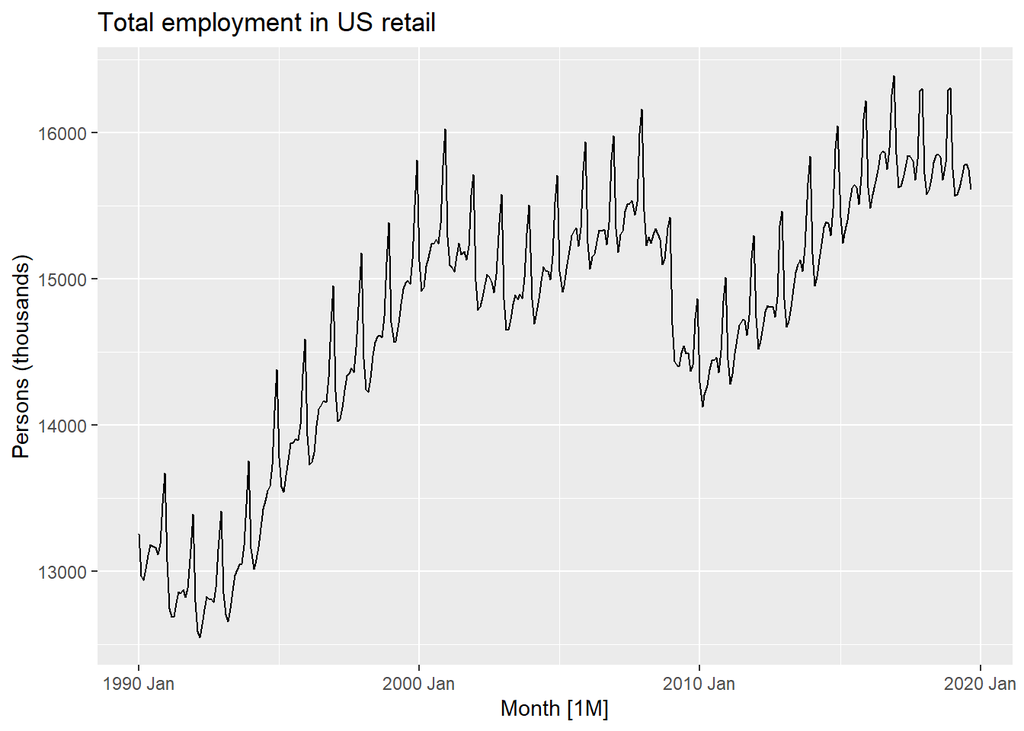

```r
us_retail_employment |>
  autoplot(Employed) +
  labs(y = "Persons (thousands)", title = "Total employment in US retail")
```

There is some trend-cycle and seasonality in this plot: The trend-cycle corresponds to the long-term rises and falls of the series over the years. We thus use STL for this series:

```r
us_retail_employment |>
  model(stl = STL(Employed))
```

```
## # A mable: 1 x 1
##       stl
##   <model>
## 1   <STL>
```

Inside this cell there is a lot of information into a “dable”:

```r
dcmp <- us_retail_employment |>
  model(stl = STL(Employed))
components(dcmp)
```

```
## # A dable: 357 x 7 [1M]
## # Key:     .model [1]
## # :        Employed = trend + season_year + remainder
##    .model     Month Employed  trend season_year remainder season_adjust
##    <chr>      <mth>    <dbl>  <dbl>       <dbl>     <dbl>         <dbl>
##  1 stl     1990 Jan   13256. 13288.      -33.0      0.836        13289.
##  2 stl     1990 Feb   12966. 13269.     -258.     -44.6          13224.
##  3 stl     1990 Mar   12938. 13250.     -290.     -22.1          13228.
##  4 stl     1990 Apr   13012. 13231.     -220.       1.05         13232.
##  5 stl     1990 May   13108. 13211.     -114.      11.3          13223.
##  6 stl     1990 Jun   13183. 13192.      -24.3     15.5          13207.
##  7 stl     1990 Jul   13170. 13172.      -23.2     21.6          13193.
##  8 stl     1990 Aug   13160. 13151.       -9.52    17.8          13169.
##  9 stl    1990 Sept   13113. 13131.      -39.5     22.0          13153.
## 10 stl     1990 Oct   13185. 13110.       61.6     13.2          13124.
## # ℹ 347 more rows
```

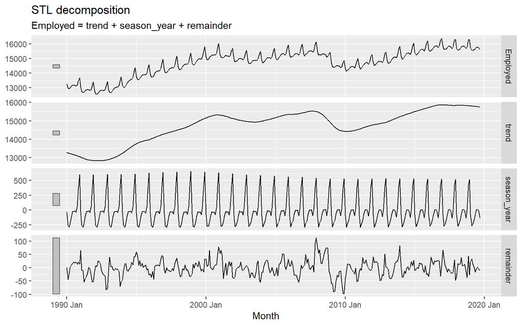

```r
components(dcmp) |> autoplot()
```

Here the seasonal pattern doesn’t seem to change much, though there is a small difference at the start, as compared to the end. Note that the gray bars give us infromation on how the different plots scale. We can also plot the trend over the original series:

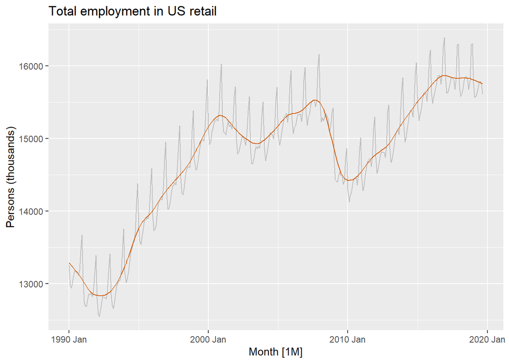

```r
us_retail_employment |>
  autoplot(Employed, color = "gray") +
  autolayer(components(dcmp), trend, color = "#D55E00") +
  labs(y = "Persons (thousands)", title = "Total employment in US retail")
```

We can also do subseries plots:

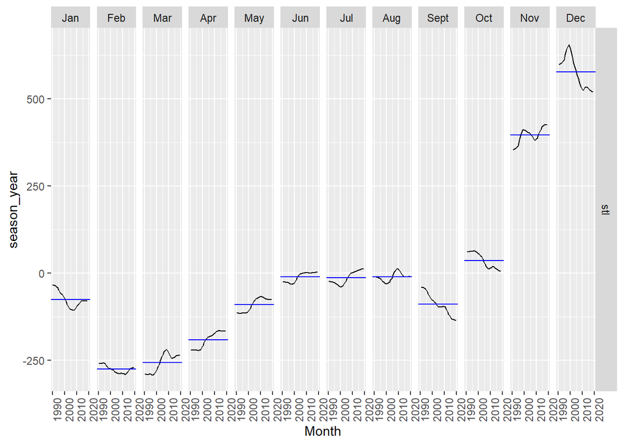

```r
components(dcmp) |> gg_subseries(season_year)
```

## Seasonal adjustment

- Useful by-product of decomposition: an easy way to calculate seasonally adjusted data.
- Additive decomposition: seasonally adjusted data given by
  $$Y_t - S_t = T_t + \varepsilon_t$$
- Multiplicative decomposition: seasonally adjusted data given by
  $$Y_t / S_t = T_t \times
  \varepsilon_t$$

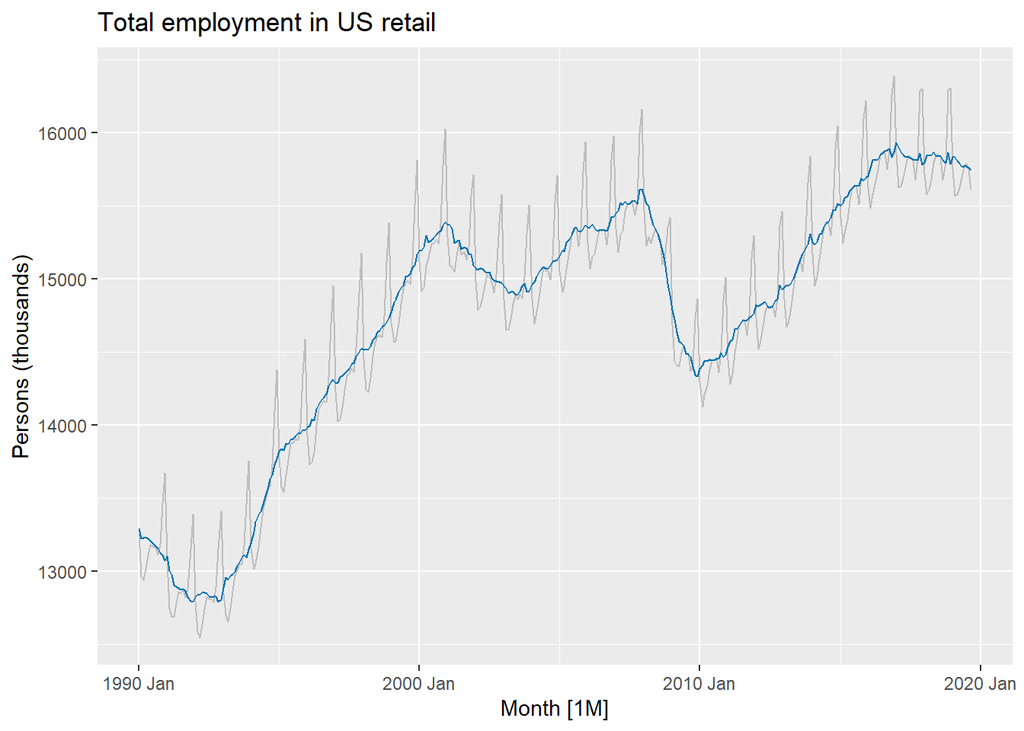

```r
us_retail_employment |>
  autoplot(Employed, color = "gray") +
  autolayer(components(dcmp), season_adjust, color = "#0072B2") +
  labs(y = "Persons (thousands)", title = "Total employment in US retail")
```

Here we plotted the trend + remainder, this is why it is less smooth

## Seasonal adjustment

- We use estimates of $S$ based on past values to seasonally adjust a current value.
- Seasonally adjusted series reflect **remainders** as well as **trend**. Therefore they are not “smooth” and “downturns” or “upturns” can be misleading.
- It is better to use the trend-cycle component to look for turning points.

## STL decomposition in Detail

- STL: “Seasonal and Trend decomposition using Loess”
- Very versatile and robust.
- Unlike X-12-ARIMA, STL will handle any type of seasonality.
- Seasonal component allowed to change over time, and rate of change controlled by user.
- Smoothness of trend-cycle also controlled by user.
- Robust to outliers
- Not trading day or calendar adjustments.
- Only additive.
- Take logs to get multiplicative decomposition.
- Use Box-Cox transformations to get other decompositions.

Now let’s try STL with different options: First the standard polot

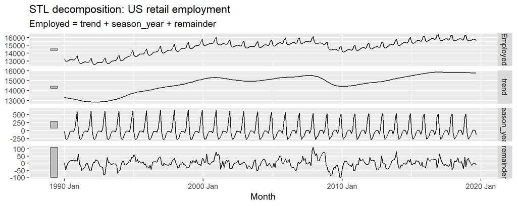

```r
us_retail_employment |>
  model(STL(Employed)) |>
  components() |>
  autoplot() + labs(title = "STL decomposition: US retail employment")
```

We see that the seasonal patterns change a bit over time. Lets say we do not want this, then we type:

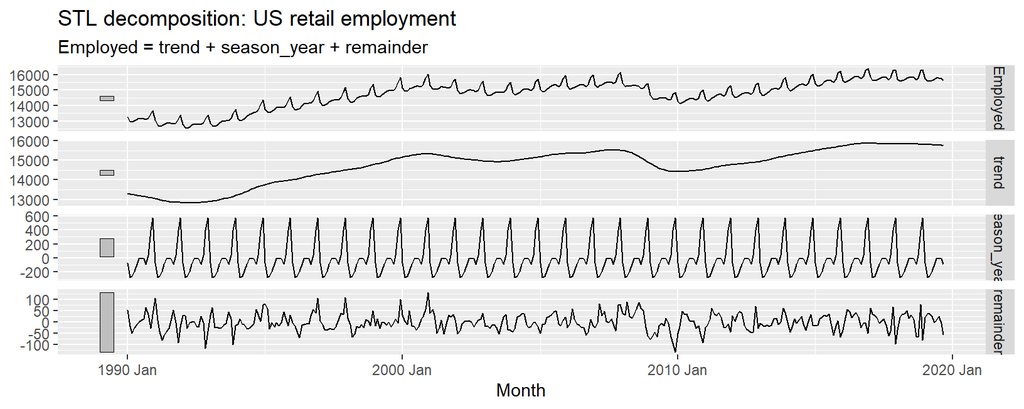

```r
us_retail_employment |>
  model(STL(Employed ~ season(window = "periodic"))) |>
  components() |>
  autoplot() + labs(title = "STL decomposition: US retail employment")
```

Now we have the same pattern every year. We can also change the number of windows that are used. The smaller this number, the more the seasonal patterns is allowed to change (we essentially use smaller windows to estimate the seasonal component):

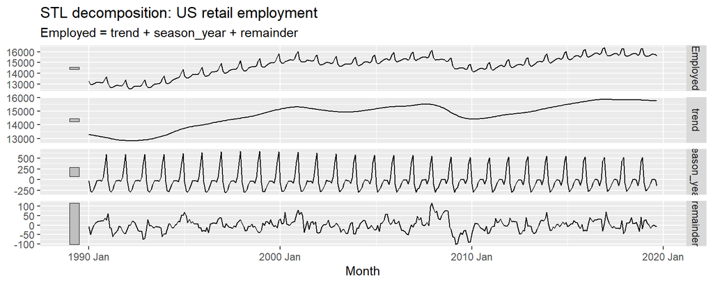

```r
us_retail_employment |>
  model(STL(Employed ~ season(window = 9))) |>
  components() |>
  autoplot() + labs(title = "STL decomposition: US retail employment")
```

We can also influence how the trend is plotted. Again, the window size allows us to influence how many windows are used to estimate the trend: The lower this number, the more ``wiggly’’ the trend is estimated. In the extreme of a very high value, the trend becomes a straight line.

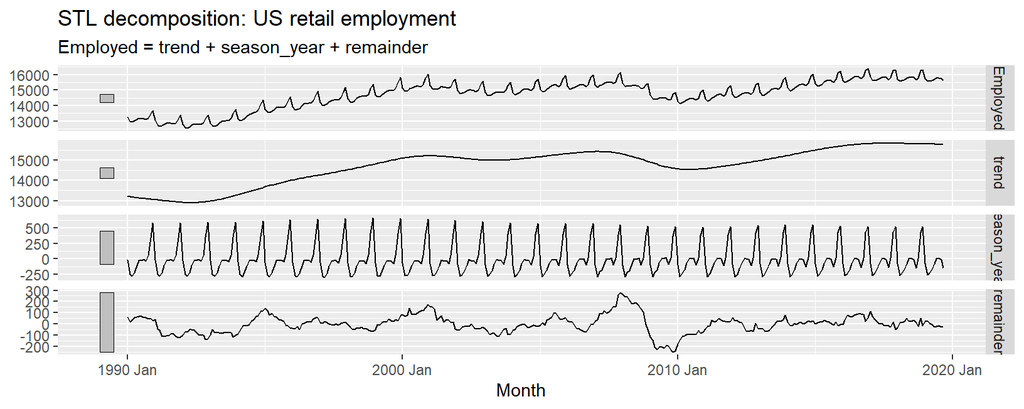

```r
us_retail_employment |>
  model(STL(Employed ~ season(window = 9) + trend(window=50))) |>
  components() |>
  autoplot() + labs(title = "STL decomposition: US retail employment")
```

We can also add the option:

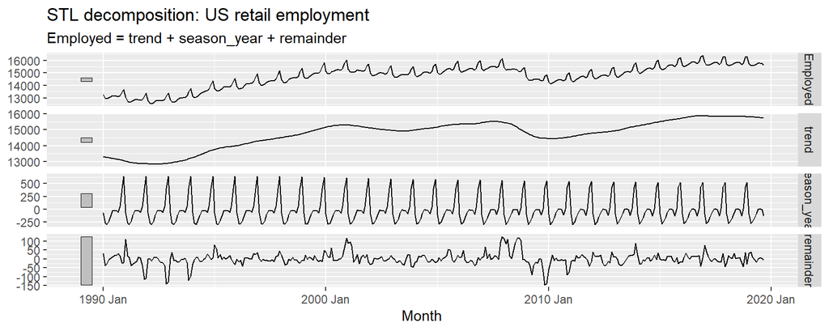

```r
us_retail_employment |>
  model(STL(Employed ~ season(window = 15) + trend(window=15), robust=T)) |>
  components() |>
  autoplot() + labs(title = "STL decomposition: US retail employment")
```

In this case ``unusual’’ observations get downweighted, so potential outliers will not influence the result too much.

```r
us_retail_employment |>
  model(STL(Employed ~ season(window = 5))) |>
  components()

us_retail_employment |>
  model(STL(
    Employed ~ trend(window = 15) +
      season(window = "periodic"),
    robust = TRUE
  )) |>
  components()
```

[output not shown]

The defaults for STL are already pretty good in most cases:

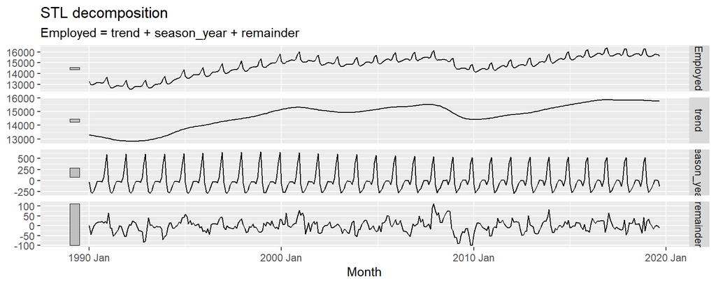

```r
us_retail_employment |>
  model(STL(Employed)) |>
  components() |>
  autoplot()
```